# PfSPZ DGE on VRC 312 & VRC 314 Datasets

Tuan M. Tran

07/15/2023

## Objective

This markdown doc creates Seq (count) and cpm expression sets for VRC 312 and VRC 314 data, does differential gene expression with edgeR, and outputs to fast GSEA using several different module types (BTMs, MSigDB collections, MonacoMods). Generates fgsea output tables that can be visualized using the “PfSPZ Import VRC 312 314 GSEA IPA for Figures.Rmd” script in “/Volumes/GoogleDrive/My Drive/Tran Lab Shared/Projects/Doris Duke PfSPZ Kenya/Tuan PfSPZ/KenyaPfSPZ/” or on the KSPZV1 github repo.

Notes: 1. For VRC 314, performed analysis on Group 1 (270K x 3 IV), Group 4 & 5 (270K x 4 IV), and Group 6 (900 x 3IV) as these were the groups with same IV dose repeated. 2. Used -log10(p) * sign(logFC) as rank metric for GSEA.

## Baseline Analysis

Run DGE, Camera, GSEA for baseline VRC 312 and VRC 314 datasets.

```r
library(doBy)
library(Biobase)
library(biomaRt)
library(edgeR)
library(genefilter)
library(NMF)
library(EDASeq)
library(tweeDEseqCountData)
library(reshape2)
library(tidyverse)
library(googledrive)
library(ggplot2)
```

```r
datadir_312 <- "/Users/tuantran/Library/CloudStorage/GoogleDrive-tuantran@iu.edu/Shared drives/[Sec] IN-MED-INF-TRANLAB/Tran Lab Shared/Projects/PfSPZ VRC RNA-seq/VRC 312/"
datadir_314 <- "/Users/tuantran/Library/CloudStorage/GoogleDrive-tuantran@iu.edu/Shared drives/[Sec] IN-MED-INF-TRANLAB/Tran Lab Shared/Projects/PfSPZ VRC RNA-seq/VRC 314/"
figdir <- "/Users/tuantran/Library/CloudStorage/OneDrive-IndianaUniversity/Manuscripts/KSPZV1 Manuscript/JCI Resubmission April 2023/Figures JCI resubmission/"
COMPARISON <- "P_vs_S_baseline"
datadir <- "/Users/tuantran/Library/CloudStorage/OneDrive-IndianaUniversity/Manuscripts/KSPZV1 Manuscript/JCI Resubmission April 2023/Prelim Results JCI resubmission/"
```

## Read in the VRC 312 and VRC 314 expression sets

Download from google drive.

```r
#VRC 312
temp <- tempfile(fileext = ".rds")
dl <- drive_download(
  as_id("1X139jUTL4lAELEA3eBTZFx2hQgmOPFSZ"), path = temp, overwrite = TRUE)
hdat_312 <- readRDS(file = dl$local_path)
#VRC 314
temp <- tempfile(fileext = ".rds")
dl <- drive_download(
  as_id("1VXTgNSQuWrsA5E-3OgOgJ-AzMZpL4afo"), path = temp, overwrite = TRUE)
hdat_314 <- readRDS(file = dl$local_path)
```

## Set options

```r
myTIMEPOINT <- "Baseline" #"Baseline"

my_VRC312_Group <- "Grp3a3b4a4b4c"
if(my_VRC312_Group == "Grp3a3b4a4b4c"){
  my_VRC312_Groups <- c("3a","3b", "4a","4b", "4c")
  }

my_VRC314_Group <- "Grp1456" #used for final analysis for reasons stated above
PCT <- 100 #used 100 PCT for final analysis

if(my_VRC314_Group == "Grp134567"){
my_VRC314_Groups <- c("Group1","Group3", "Group4","Group5", "Group6", "Group7") # "Group6" #Group2 is IM
}
if(my_VRC314_Group == "Grp567"){
my_VRC314_Groups <- c("Group5", "Group6","Group7")
}
if(my_VRC314_Group == "Grp1456"){
my_VRC314_Groups <- c("Group1", "Group4", "Group5", "Group6")
}
```

### Reduce datasets to relevant samples

```r
hdat_312 <- hdat_312[,which(hdat_312$Dose.group != "EXT")]
hdat_312$Dose.group <- droplevels(hdat_312$Dose.group)

#remove outcome = N/A
hdat_312 <- hdat_312[,!is.na(hdat_312$Outcome.Final)]
hdat_312$Outcome.Final <- droplevels(hdat_312$Outcome.Final)
foo <- hdat_312[,hdat_312$Patient == 331 & grepl("Imm5",hdat_312$Dose.group)] #Remove 331 Imm5 (failed QC)
hdat_312 <- hdat_312[,setdiff(colnames(hdat_312),colnames(foo))]

hdat_312 <- hdat_312[,which(grepl(myTIMEPOINT, hdat_312$Dose.group))]
hdat_312 <- hdat_312[,which(hdat_312$Outcome.Final != "N/A")]
hdat_312$Dose.group <- droplevels(hdat_312$Dose.group)
hdat_312$Outcome.Final <- factor(hdat_312$Outcome.Final)
hdat_312$Outcome.Final <- droplevels(hdat_312$Outcome.Final)

#Filter on Group
hdat_312 <- hdat_312[,which(hdat_312$Group %in% my_VRC312_Groups)]
hdat_312$Group <- factor(hdat_312$Group)
hdat_312$Group <- droplevels(hdat_312$Group)
table(hdat_312$Group,hdat_312$Outcome.Final)
```

```
##
##      Malaria Protected
##   3a       3         0
##   3b       8         1
##   4a       0         2
##   4b       0         4
##   4c       3         6
```

```r
table(hdat_312$Dose.group,hdat_312$Outcome.Final)
```

```
##
##                 Malaria Protected
##   Baseline. D01      14        13
```

[output not shown]

[output not shown]

# VRC 312 Analysis

## Make DGElist object VRC 312

```r
# Make DGElist object
y_VRC312   <- DGEList(count = counts(hdat_312), genes= fData(hdat_312), samples = pData(hdat_312), group= hdat_312$Group, remove.zeros=T)
```

## Filter genes VRC 312

```r
filter.type <- "-low_express_filter-"
dim(y_VRC312)
```

```
## [1] 18580    27
```

```r
#Filter low expression tags: keep genes with at least 1 CPM in at least X, where X is the number of samples in the smallest group (exclude controls by using foo.dat above)
keep <- filterByExpr(y_VRC312)
y_VRC312 <- y_VRC312[keep, , keep.lib.sizes=FALSE]
dim(y_VRC312)
```

```
## [1] 13713    27
```

## Normalization VRC 312

```r
y_VRC312$samples$lib.size <- colSums(y_VRC312$counts)
y_VRC312 <- calcNormFactors(y_VRC312)           #Normalization, use scale (TMM) here or quantile normalization later with voom, but not both
#reference for this here: https://support.bioconductor.org/p/77664/
dim(y_VRC312)
```

```
## [1] 13713    27
```

## Linear modeling VRC 312

Using edgeR with batch adjustment

```r
# create design matrix according to Limma user guide (Ch 9.7 Multi Level Experiments)
# http://www.bioconductor.org/packages/release/bioc/vignettes/limma/inst/doc/usersguide.pdf and
# http://permalink.gmane.org/gmane.science.biology.informatics.conductor/48432
Group   <-   factor(y_VRC312$samples$Group)
Outcome <-   y_VRC312$sample$Outcome.Final
Timept  <-   y_VRC312$sample$Dose.group
Dose    <-   factor(y_VRC312$sample$Dose)
Batch1  <-   factor(y_VRC312$sample$BatchNumber)
Batch2  <-   factor(y_VRC312$sample$Date.Extracted)
Batch   <-   as.factor(paste(as.character(Batch1), as.character(Batch2), sep="_"))
Subject <-   as.factor(as.character(y_VRC312$sample$Patient))
Gender  <-   as.factor(as.character(y_VRC312$sample$Gender))
Outcome_Timept <- factor(paste(Outcome,Timept,sep="_"))
#design <- model.matrix(~0 + Outcome + Batch1 + Batch2) # batch corrected; baseline only
design <- model.matrix(~0 + Gender + Group + Batch1 + Batch2 + Outcome) # dose adjusted; batch corrected; edgeR
#design <- model.matrix(~0 + Outcome_Timept + Dose + Batch1 + Batch2) # batch corrected; dose adjusted; use limma pairing method
rownames(design) <- Subject
colnames(design) <- gsub(":", "_", colnames(design))
colnames(design) <- gsub(". ", "_", colnames(design))
colnames(design) <- gsub("/", "_", colnames(design))
colnames(design) <- gsub("Outcome_Timept", "", colnames(design))
colnames(design) <- gsub("Outcome", "", colnames(design))
colnames(design) <- gsub("Timept", "", colnames(design))
colnames(design) <- gsub("_Dose", "", colnames(design))
design <- design[,!(colSums(design) == 0)]          #remove columns with all zeros

##################################
#Remove Columns not of Full Rank #
##################################
#Error in glmFit.default(sely, design, offset = seloffset, dispersion = 0.05, : Design matrix not of full rank. The following coefficients not estimable: Batch28_18_14 Batch28_6_14
design <- design[,colnames(design)!="Batch28_18_14"]
design <- design[,colnames(design)!="Batch28_6_14"]
colnames(design)
```

```
##  [1] "GenderFemale"  "GenderMale"    "Group3b"       "Group4a"
##  [5] "Group4b"       "Group4c"       "Batch12"       "Batch13"
##  [9] "Batch14"       "Batch15"       "Batch16"       "Batch17"
## [13] "Batch18"       "Batch19"       "Batch27_28_14" "Batch27_30_14"
## [17] "Batch28_11_14" "Batch28_12_14" "Batch28_14_14" "Batch28_4_14"
## [21] "Protected"
```

## Estimate Dispersions VRC 312

```r
y_VRC312 <- estimateDisp(y_VRC312,design)
```

## Perform Differential Gene expression VRC 312

```r
fit <- glmQLFit(y_VRC312, design, robust = TRUE)
qlf <- glmQLFTest(fit, contrast = c(rep(0,(ncol(design)-1)),1))
TopTab_VRC312 <- topTags(qlf, n = nrow(y_VRC312))$table
```

### Examine top 15 DEGs (protected vs not protected) VRC 312

VRC 312 DEGs

```r
TopTab_VRC312 %>%
  arrange(PValue) %>%
  slice_head(., n=15) %>%
  knitr::kable()
```

|  | hgnc_symbol | Gene_length | logFC | logCPM | F | PValue | FDR |
| --- | --- | --- | --- | --- | --- | --- | --- |
| DSP | DSP | 45143 | -7.183389 | 0.7967667 | 30.37105 | 0.0001351 | 0.9992151 |
| MIR3064 | MIR3064 | 66 | 1.664129 | 3.9692527 | 23.30617 | 0.0003663 | 0.9992151 |
| MYOM2 | MYOM2 | 120513 | -3.497329 | 3.9798956 | 22.01934 | 0.0006644 | 0.9992151 |
| KLF4 | KLF4 | 5631 | -1.567225 | 4.9953269 | 19.12717 | 0.0008207 | 0.9992151 |
| GATA2 | GATA2 | 13759 | -2.329341 | 4.4725484 | 19.54625 | 0.0008238 | 0.9992151 |
| KLRC2 | KLRC2 | 15447 | 2.789431 | 0.7660376 | 18.38370 | 0.0009586 | 0.9992151 |
| CPA3 | CPA3 | 31941 | -2.031665 | 3.0558436 | 17.45434 | 0.0011705 | 0.9992151 |
| KLRD1 | KLRD1 | 103543 | 1.479332 | 5.9226770 | 17.06916 | 0.0012741 | 0.9992151 |
| CRIP2 | CRIP2 | 7209 | -2.042987 | 4.2468984 | 16.13106 | 0.0016270 | 0.9992151 |
| N4BP2L2-IT2 | N4BP2L2-IT2 | 4890 | 1.260956 | 3.7626414 | 15.52629 | 0.0018113 | 0.9992151 |
| DEFA4 | DEFA4 | 2517 | 2.021364 | 2.9653200 | 14.91959 | 0.0020920 | 0.9992151 |
| FLVCR1-AS1 | FLVCR1-AS1 | 5981 | -2.348873 | 1.5393094 | 14.84552 | 0.0021297 | 0.9992151 |
| LIMS2 | LIMS2 | 43406 | -1.511498 | 3.2091759 | 14.37374 | 0.0023888 | 0.9992151 |
| GZMH | GZMH | 3220 | 1.712349 | 5.9327718 | 14.42462 | 0.0023979 | 0.9992151 |
| CLEC1A | CLEC1A | 42074 | 2.205862 | 1.2225068 | 14.18275 | 0.0025040 | 0.9992151 |

## Camera VRC 312

### Competitive gene set test accounting for inter-gene correlation between “protected” vs “not protected”

Uses Camera: https://academic.oup.com/nar/article/40/17/e133/2411151

high BTMs

```r
i <- "highBTMs"
url <- paste0("https://github.com/TranLab/ModuleLists/blob/main/", i, ".rds?raw=true")
highBTM_list <- readRDS(url(url, method="libcurl"))
highBTM.indices <- ids2indices(highBTM_list, y_VRC312$genes$hgnc_symbol)
cameratab_VRC312_hibtms <- camera(y_VRC312, highBTM.indices, design, contrast = c(rep(0, ncol(design)-1),1), inter.gene.cor=0.01) %>%
  rownames_to_column(var="module") %>%
  mutate(study = "VRC312") %>%
  mutate(module_type = "high BTMs") %>%
  dplyr::select(study, module_type, module, everything())
cameratab_VRC312_hibtms %>%
  filter(FDR<0.05) %>%
  knitr::kable()
```

| study | module_type | module | NGenes | Direction | PValue | FDR |
| --- | --- | --- | --- | --- | --- | --- |
| VRC312 | high BTMs | NK CELLS | 85 | Up | 0.0000000 | 0.0000000 |
| VRC312 | high BTMs | MONOCYTES | 305 | Down | 0.0000002 | 0.0000016 |
| VRC312 | high BTMs | Mitochondrial | 63 | Down | 0.0002725 | 0.0011593 |
| VRC312 | high BTMs | INTERFERON/ANTIVIRAL SENSING | 65 | Down | 0.0003505 | 0.0011593 |
| VRC312 | high BTMs | DC ACTIVATION | 125 | Down | 0.0004140 | 0.0011593 |
| VRC312 | high BTMs | ECM AND MIGRATION | 188 | Down | 0.0045887 | 0.0107070 |
| VRC312 | high BTMs | CELL CYCLE | 446 | Down | 0.0081136 | 0.0151779 |
| VRC312 | high BTMs | PLASMA CELLS | 48 | Down | 0.0090914 | 0.0151779 |
| VRC312 | high BTMs | INFLAMMATORY/TLR/CHEMOKINES | 478 | Down | 0.0097572 | 0.0151779 |

low BTMs

```r
i <- "lowBTMs"
url <- paste0("https://github.com/TranLab/ModuleLists/blob/main/", i, ".rds?raw=true")
lowBTM_list <- readRDS(url(url, method="libcurl"))
lowBTM.indices <- ids2indices(lowBTM_list, y_VRC312$genes$hgnc_symbol)
cameratab_VRC312_lowbtms <- camera(y_VRC312, lowBTM.indices, design, contrast = c(rep(0, ncol(design)-1),1), inter.gene.cor=0.01) %>%
  rownames_to_column(var="module") %>%
  mutate(study = "VRC312") %>%
  mutate(module_type = "low BTMs") %>%
  dplyr::select(study, module_type, module, everything())
cameratab_VRC312_lowbtms %>%
  filter(FDR<0.05) %>%
  knitr::kable()
```

| study | module_type | module | NGenes | Direction | PValue | FDR |
| --- | --- | --- | --- | --- | --- | --- |
| VRC312 | low BTMs | enriched in NK cells (I) (M7.2) | 44 | Up | 0.0000000 | 0.0000000 |
| VRC312 | low BTMs | cell adhesion (M51) | 22 | Down | 0.0000000 | 0.0000000 |
| VRC312 | low BTMs | platelet activation & blood coagulation (M199) | 12 | Down | 0.0000001 | 0.0000065 |
| VRC312 | low BTMs | enriched in monocytes (II) (M11.0) | 182 | Down | 0.0000016 | 0.0001338 |
| VRC312 | low BTMs | enriched in myeloid cells and monocytes (M81) | 34 | Down | 0.0000141 | 0.0009751 |
| VRC312 | low BTMs | Ran mediated mitosis (M15) | 13 | Down | 0.0000628 | 0.0036083 |
| VRC312 | low BTMs | cell division in stimulated CD4+ T cells (M46) | 26 | Down | 0.0000755 | 0.0037233 |
| VRC312 | low BTMs | enriched in NK cells (III) (M157) | 13 | Up | 0.0001231 | 0.0044070 |
| VRC312 | low BTMs | cell cycle and transcription (M4.0) | 308 | Down | 0.0001251 | 0.0044070 |
| VRC312 | low BTMs | enriched in T cells (I) (M7.0) | 55 | Up | 0.0001344 | 0.0044070 |
| VRC312 | low BTMs | cell movement, Adhesion & Platelet activation (M30) | 19 | Down | 0.0001405 | 0.0044070 |
| VRC312 | low BTMs | platelet activation - actin binding (M196) | 15 | Down | 0.0001621 | 0.0044776 |
| VRC312 | low BTMs | AP-1 transcription factor network (M20) | 11 | Down | 0.0001687 | 0.0044776 |
| VRC312 | low BTMs | Resting dendritic cell surface signature (S10) | 66 | Down | 0.0001912 | 0.0047121 |
| VRC312 | low BTMs | TBA (M218) | 13 | Up | 0.0002150 | 0.0049444 |
| VRC312 | low BTMs | plasma cells, immunoglobulins (M156.1) | 7 | Down | 0.0002651 | 0.0056249 |
| VRC312 | low BTMs | respiratory electron transport chain (mitochondrion) (M219) | 18 | Down | 0.0002772 | 0.0056249 |
| VRC312 | low BTMs | putative targets of PAX3 (M89.0) | 13 | Down | 0.0003698 | 0.0069612 |
| VRC312 | low BTMs | NK cell surface signature (S1) | 37 | Up | 0.0003834 | 0.0069612 |
| VRC312 | low BTMs | respiratory electron transport chain (mitochondrion) (M238) | 17 | Down | 0.0004727 | 0.0081545 |
| VRC312 | low BTMs | growth factor induced, enriched in nuclear receptor subfamily 4 (M94) | 8 | Down | 0.0005057 | 0.0083048 |
| VRC312 | low BTMs | golgi membrane (II) (M237) | 17 | Up | 0.0005296 | 0.0083048 |
| VRC312 | low BTMs | suppression of MAPK signaling (M56) | 12 | Down | 0.0005642 | 0.0084349 |
| VRC312 | low BTMs | cell cycle and growth arrest (M31) | 10 | Down | 0.0005868 | 0.0084349 |
| VRC312 | low BTMs | TBA (M72.1) | 15 | Up | 0.0006977 | 0.0096282 |
| VRC312 | low BTMs | Monocyte surface signature (S4) | 83 | Down | 0.0011574 | 0.0150319 |
| VRC312 | low BTMs | enriched in NK cells (receptor activation) (M61.2) | 11 | Up | 0.0011764 | 0.0150319 |
| VRC312 | low BTMs | putative targets of PAX3 (M89.1) | 9 | Down | 0.0012575 | 0.0154936 |
| VRC312 | low BTMs | enriched in NK cells (II) (M61.0) | 14 | Up | 0.0014056 | 0.0167219 |
| VRC312 | low BTMs | TBA (M55) | 12 | Down | 0.0015826 | 0.0178549 |

[output cut: 68 more lines]

Monaco et al. modules

```r
i <- "MonacoModules"
url <- paste0("https://github.com/TranLab/ModuleLists/blob/main/", i, ".rds?raw=true")
MonacoModules_list <- readRDS(url(url, method="libcurl"))
MonacoModules.indices <- ids2indices(MonacoModules_list, y_VRC312$genes$hgnc_symbol)
cameratab_VRC312_MonacoModules <- camera(y_VRC312, MonacoModules.indices, design, contrast = c(rep(0, ncol(design)-1),1), inter.gene.cor=0.01) %>%
  rownames_to_column(var="module") %>%
  mutate(study = "VRC312") %>%
  mutate(module_type = "Monaco modules") %>%
  dplyr::select(study, module_type, module, everything())
cameratab_VRC312_MonacoModules %>%
  filter(FDR<0.05) %>%
  knitr::kable()
```

| study | module_type | module | NGenes | Direction | PValue | FDR |
| --- | --- | --- | --- | --- | --- | --- |
| VRC312 | Monaco modules | T gd non-Vd2 | 31 | Up | 0.0000000 | 0.0000005 |
| VRC312 | Monaco modules | NK | 60 | Up | 0.0000010 | 0.0000087 |
| VRC312 | Monaco modules | T CD8 Memory | 17 | Up | 0.0000024 | 0.0000138 |
| VRC312 | Monaco modules | Monocytes NC+I | 65 | Down | 0.0000035 | 0.0000148 |
| VRC312 | Monaco modules | mDCs | 165 | Down | 0.0004064 | 0.0013818 |
| VRC312 | Monaco modules | Monocytes C | 54 | Down | 0.0009771 | 0.0027684 |
| VRC312 | Monaco modules | T CD4 Memory | 30 | Down | 0.0011555 | 0.0028062 |
| VRC312 | Monaco modules | T CD8 Naive | 48 | Up | 0.0088671 | 0.0188425 |
| VRC312 | Monaco modules | Basophils LD | 23 | Down | 0.0122707 | 0.0231779 |
| VRC312 | Monaco modules | T gd Vd2 | 28 | Up | 0.0160941 | 0.0254104 |
| VRC312 | Monaco modules | Neutrophils LD | 46 | Down | 0.0164420 | 0.0254104 |
| VRC312 | Monaco modules | MAIT | 38 | Down | 0.0181913 | 0.0257709 |
| VRC312 | Monaco modules | Plasmablasts | 65 | Down | 0.0205818 | 0.0269146 |

HALLMARK

```r
i <- "MSigDB_Hallmark_v7.4"
url <- paste0("https://github.com/TranLab/ModuleLists/blob/main/", i, ".rds?raw=true")
HALLMARK_list <- readRDS(url(url, method="libcurl"))
HALLMARK.indices <- ids2indices(HALLMARK_list, y_VRC312$genes$hgnc_symbol)
cameratab_VRC312_HALLMARK <- camera(y_VRC312, HALLMARK.indices, design, contrast = c(rep(0, ncol(design)-1),1), inter.gene.cor=0.01) %>%
  rownames_to_column(var="module") %>%
  mutate(study = "VRC312") %>%
  mutate(module_type = "HALLMARK") %>%
  dplyr::select(study, module_type, module, everything())
cameratab_VRC312_HALLMARK %>%
  filter(FDR<0.05) %>%
  knitr::kable()
```

| study | module_type | module | NGenes | Direction | PValue | FDR |
| --- | --- | --- | --- | --- | --- | --- |
| VRC312 | HALLMARK | HALLMARK_TNFA_SIGNALING_VIA_NFKB | 181 | Down | 0.0000182 | 0.0009120 |
| VRC312 | HALLMARK | HALLMARK_COAGULATION | 91 | Down | 0.0000381 | 0.0009523 |
| VRC312 | HALLMARK | HALLMARK_IL6_JAK_STAT3_SIGNALING | 76 | Down | 0.0005375 | 0.0089588 |
| VRC312 | HALLMARK | HALLMARK_MYOGENESIS | 136 | Down | 0.0017605 | 0.0220056 |
| VRC312 | HALLMARK | HALLMARK_PROTEIN_SECRETION | 90 | Up | 0.0045238 | 0.0452383 |

### Apply GSEA VRC 312

Rank genes by -log10(PValue)*sign(logFC). Run fgsea from fgsea package using NamedGeneRankList2GseaTable helper function.

```r
set.seed(23)
ranks_VRC312 <- TopTab_VRC312 %>%
  mutate(rankmetric = -log10(.$PValue)*sign(.$logFC)) %>%
  dplyr::select(hgnc_symbol,rankmetric) %>%
  na.omit() %>%
  distinct() %>%
  group_by(hgnc_symbol) %>%
  summarize(rankmetric = mean(rankmetric)) %>%
  arrange(desc(rankmetric)) %>%
  deframe()

#Run fgsea from fgsea package using NamedGeneRankList2GseaTable helper function
devtools::source_url("https://github.com/TranLab/ModuleLists/blob/main/NamedGeneRankList2GseaTable.R?raw=TRUE")
GSEAtab_VRC312 <- NamedGeneRankList2GseaTable(rankedgenes = ranks_VRC312,
                                       geneset = "all",
                                       output_directory = tempdir(),
                                       filename_prefix = "GSEA",
                                       sampleSize = 101,
                                       minSize = 20,
                                       maxSize = Inf,
                                       scoreType = "std") %>%
  as_tibble() %>%
  arrange(desc(NES)) %>%
  mutate(study = "VRC312") %>%
  dplyr::select(study, module_type, pathway, ES, NES, size, leadingEdge, pval, padj) %>%
  mutate(leadingEdge = gsub("^c\\(|\\)$", "", leadingEdge)) %>%
  mutate(leadingEdge = gsub('"', "", leadingEdge)) %>%
  arrange(padj)
```

```
## [1] "Running fgsea for MonacoModules signatures"
## [1] "Running fgsea for highBTMs signatures"
## [1] "Running fgsea for lowBTMs signatures"
## [1] "Running fgsea for BloodGen3Module signatures"
## [1] "Running fgsea for MSigDB_Hallmark_v7.4 signatures"
## [1] "Running fgsea for MSigDB_C2_biocarta_v7.4 signatures"
## [1] "Running fgsea for MSigDB_C2_kegg_v7.4 signatures"
## [1] "Running fgsea for MSigDB_C8_all_v7.4 signatures"
## [1] "Running fgsea for MSigDB_C7_all_v7.4 signatures"
## [1] "Running fgsea for MSigDB_C5_GO_bp_v7.4 signatures"
## [1] "Running fgsea for MSigDB_C5_GO_mf_v7.4 signatures"
```

# VRC 314 Analysis

## Make DGElist object VRC 314

```r
y_VRC314   <- DGEList(count = counts(hdat_314), genes= fData(hdat_314), samples = pData(hdat_314),group= hdat_314$Outcome.Final, remove.zeros=T)
```

## Filter genes VRC 314

```r
filter.type <- "-low_express_filter-"
dim(y_VRC314)
```

```
## [1] 17699    34
```

```r
#Filter low expression tags: keep genes with at least 1 CPM in at least X, where X is the number of samples in the smallest group (exclude controls by using foo.dat above)
keep <- filterByExpr(y_VRC314, group = hdat_314$Outcome.Final)
y_VRC314 <- y_VRC314[keep, , keep.lib.sizes=FALSE]
dim(y_VRC314)
```

```
## [1] 12059    34
```

## Normalization VRC 314

```r
###############
y_VRC314$samples$lib.size <- colSums(y_VRC314$counts)
y_VRC314 <- calcNormFactors(y_VRC314)           #Normalization, use scale (TMM) here or quantile normalization later with voom, but not both
#reference for this here: https://support.bioconductor.org/p/77664/
dim(y_VRC314)
```

```
## [1] 12059    34
```

```r
logcpm_314 <- cpm(y_VRC314, prior.count = 0.25,log=T)
```

## Filter by library size VRC 314

Note that expression set already has been filtered.

```r
y_VRC314 <- y_VRC314[,y_VRC314$samples$lib.size>7.5e6]
```

## Linear modeling VRC 314

Use edgeR with batch adjustment

```r
# create design matrix according to Limma user guide (Ch 9.7 Multi Level Experiments)
# http://www.bioconductor.org/packages/release/bioc/vignettes/limma/inst/doc/usersguide.pdf and
# http://permalink.gmane.org/gmane.science.biology.informatics.conductor/48432

Outcome <- y_VRC314$samples$Outcome.Final
Timept <- y_VRC314$samples$Dose.group
Sex <- factor(y_VRC314$samples$Gender)
Batch1  <-   factor(y_VRC314$samples$Lib_Batch)
Batch2  <-   factor(y_VRC314$samples$Date)
Batch   <-   as.factor(paste(as.character(Batch1), as.character(Batch2), sep="_"))
Group <- factor(y_VRC314$samples$Group)
Subject <-   y_VRC314$samples$Patient
Outcome_Timept <- factor(paste(Outcome,Timept,sep="_"))
design <- model.matrix(~0 + Group + Sex + Batch + Outcome) # GROUP and BATCH corrected
rownames(design) <- Subject
colnames(design) <- gsub(":", "_", colnames(design))
colnames(design) <- gsub("\\.", "_", colnames(design))
colnames(design) <- gsub(", ", "_", colnames(design))
colnames(design) <- gsub(" \\+ ", "_", colnames(design))
colnames(design) <- gsub("CHMI 1", "CHMI1", colnames(design))
colnames(design) <- gsub(" ", "_", colnames(design))
colnames(design) <- gsub("Outcome_Timept", "", colnames(design))
colnames(design) <- gsub("Outcome", "", colnames(design))
colnames(design) <- gsub("Timept", "", colnames(design))
design <- design[,!(colSums(design) == 0)]          #remove columns with all zeros

# When running myGroup = Grp1456
# Design matrix not of full rank.  The following coefficients not estimable:
#  Batch4_Jun_27_2016 Batch5_March_23_2016 Batch5_Nov_24_2015
#for Grp
if(my_VRC314_Group == "Grp1456"){
  design <- design[,!colnames(design)%in%c("Batch4_Jun_27_2016", "Batch5_March_23_2016", "Batch5_Nov_24_2015")]
}
colnames(design)
```

```
##  [1] "GroupGroup1"          "GroupGroup4"          "GroupGroup5"
##  [4] "GroupGroup6"          "SexMale"              "Batch1_Jun_27_2016"
##  [7] "Batch1_March_23_2016" "Batch2_Dec_14_2015"   "Batch2_Feb_15_2016"
## [10] "Batch2_Jun_27_2016"   "Batch2_March_22_2016" "Batch2_March_23_2016"
## [13] "Batch3_Dec_14_2015"   "Batch3_Feb_15_2016"   "Batch3_March_22_2016"
## [16] "Batch3_March_23_2016" "Batch4_Feb_15_2016"   "Batch4_March_23_2016"
## [19] "Batch5_Feb_15_2016"   "Batch5_Jan_10_2017"   "Batch5_Nov_23_2015"
## [22] "Protected"
```

## Estimate Dispersions VRC 314

```r
y_VRC314 <- estimateDisp(y_VRC314,design)
```

## Perform Differential Gene expression VRC 314

```r
fit <- glmQLFit(y_VRC314, design, robust = TRUE)
qlf <- glmQLFTest(fit, contrast = c(rep(0,(ncol(design)-1)),1))
TopTab_VRC314 <- topTags(qlf, n = nrow(y_VRC314))$table
```

### Examine top 15 DEGs (protected vs not protected) VRC 314

VRC 314 DEGs

```r
TopTab_VRC314 %>%
  arrange(PValue) %>%
  slice_head(., n=15) %>%
  knitr::kable()
```

|  | hgnc_symbol | Gene_length | logFC | logCPM | F | PValue | FDR |
| --- | --- | --- | --- | --- | --- | --- | --- |
| LSM3 | LSM3 | 22762 | 1.2534945 | 2.0450348 | 19.02542 | 0.0003816 | 0.9995008 |
| RSL24D1 | RSL24D1 | 16262 | 0.8916864 | 4.1146619 | 18.79948 | 0.0004041 | 0.9995008 |
| MRPL22 | MRPL22 | 28342 | 0.8539825 | 2.0954515 | 18.30556 | 0.0004587 | 0.9995008 |
| HMGB2 | HMGB2 | 3431 | 0.5954213 | 5.9447479 | 18.23662 | 0.0004670 | 0.9995008 |
| PKMYT1 | PKMYT1 | 12516 | 1.3627389 | 0.9853329 | 17.67822 | 0.0005402 | 0.9995008 |
| RPAP2 | RPAP2 | 103092 | 0.6424314 | 2.6740872 | 16.65790 | 0.0007097 | 0.9995008 |
| LRRN3 | LRRN3 | 34449 | 0.5701528 | 5.0630690 | 16.03700 | 0.0008415 | 0.9995008 |
| ERH | ERH | 18505 | 0.5006289 | 4.9424513 | 15.49000 | 0.0009806 | 0.9995008 |
| TOP2A | TOP2A | 29435 | 1.1330862 | 2.0631916 | 15.36119 | 0.0010169 | 0.9995008 |
| EIF3E | EIF3E | 234118 | 0.5347341 | 5.5085325 | 15.14272 | 0.0010821 | 0.9995008 |
| HAT1 | HAT1 | 61235 | 0.7044486 | 3.7125303 | 14.90245 | 0.0011592 | 0.9995008 |
| RPF1 | RPF1 | 18532 | 0.4450407 | 4.3677015 | 14.53970 | 0.0012876 | 0.9995008 |
| TNFRSF17 | TNFRSF17 | 2962 | 1.0589016 | 2.0137156 | 14.42307 | 0.0013322 | 0.9995008 |
| KIAA0391 | KIAA0391 | 155769 | 0.4018734 | 4.9269749 | 14.26914 | 0.0013937 | 0.9995008 |
| RPL23P8 | RPL23P8 | 428 | 1.1001535 | 3.3326897 | 13.87118 | 0.0016220 | 0.9995008 |

## Camera VRC 314

### Competitive gene set test accounting for inter-gene correlation between “protected” vs “not protected”

Uses Camera: https://academic.oup.com/nar/article/40/17/e133/2411151

high BTMs

```r
i <- "highBTMs"
url <- paste0("https://github.com/TranLab/ModuleLists/blob/main/", i, ".rds?raw=true")
highBTM_list <- readRDS(url(url, method="libcurl"))
highBTM.indices <- ids2indices(highBTM_list, y_VRC314$genes$hgnc_symbol)
cameratab_VRC314_hibtms <- camera(y_VRC314, highBTM.indices, design, contrast = c(rep(0, ncol(design)-1),1), inter.gene.cor=0.01) %>%
  rownames_to_column(var="module") %>%
  mutate(study = "VRC314") %>%
  mutate(module_type = "high BTMs") %>%
  dplyr::select(study, module_type, module, everything())
cameratab_VRC314_hibtms %>%
  filter(FDR<0.05) %>%
  knitr::kable()
```

| study | module_type | module | NGenes | Direction | PValue | FDR |
| --- | --- | --- | --- | --- | --- | --- |
| VRC314 | high BTMs | MONOCYTES | 302 | Down | 0.0000015 | 0.0000203 |
| VRC314 | high BTMs | NEUTROPHILS | 70 | Down | 0.0000042 | 0.0000293 |
| VRC314 | high BTMs | Mitochondrial | 63 | Up | 0.0000067 | 0.0000311 |
| VRC314 | high BTMs | CELL CYCLE | 412 | Up | 0.0048194 | 0.0152290 |
| VRC314 | high BTMs | ECM AND MIGRATION | 180 | Down | 0.0054389 | 0.0152290 |

low BTMs

```r
i <- "lowBTMs"
url <- paste0("https://github.com/TranLab/ModuleLists/blob/main/", i, ".rds?raw=true")
lowBTM_list <- readRDS(url(url, method="libcurl"))
lowBTM.indices <- ids2indices(lowBTM_list, y_VRC314$genes$hgnc_symbol)
cameratab_VRC314_lowbtms <- camera(y_VRC314, lowBTM.indices, design, contrast = c(rep(0, ncol(design)-1),1), inter.gene.cor=0.01) %>%
  rownames_to_column(var="module") %>%
  mutate(study = "VRC314") %>%
  mutate(module_type = "low BTMs") %>%
  dplyr::select(study, module_type, module, everything())
cameratab_VRC314_lowbtms%>%
  filter(FDR<0.05) %>%
  knitr::kable()
```

| study | module_type | module | NGenes | Direction | PValue | FDR |
| --- | --- | --- | --- | --- | --- | --- |
| VRC314 | low BTMs | cell cycle (I) (M4.1) | 110 | Up | 0.0000000 | 0.0000000 |
| VRC314 | low BTMs | proteasome (M226) | 12 | Up | 0.0000000 | 0.0000000 |
| VRC314 | low BTMs | mitotic cell cycle in stimulated CD4 T cells (M4.5) | 28 | Up | 0.0000000 | 0.0000017 |
| VRC314 | low BTMs | C-MYC transcriptional network (M4.12) | 11 | Up | 0.0000001 | 0.0000047 |
| VRC314 | low BTMs | spliceosome (M250) | 11 | Up | 0.0000001 | 0.0000047 |
| VRC314 | low BTMs | mitotic cell cycle (M4.7) | 15 | Up | 0.0000005 | 0.0000260 |
| VRC314 | low BTMs | cell cycle (III) (M103) | 46 | Up | 0.0000006 | 0.0000269 |
| VRC314 | low BTMs | TBA (M174) | 22 | Up | 0.0000006 | 0.0000269 |
| VRC314 | low BTMs | cell division in stimulated CD4+ T cells (M46) | 24 | Up | 0.0000008 | 0.0000302 |
| VRC314 | low BTMs | mitotic cell division (M6) | 20 | Up | 0.0000009 | 0.0000308 |
| VRC314 | low BTMs | platelet activation & blood coagulation (M199) | 12 | Down | 0.0000012 | 0.0000365 |
| VRC314 | low BTMs | cell cycle, ATP binding (M144) | 15 | Up | 0.0000067 | 0.0001748 |
| VRC314 | low BTMs | cell cycle (II) (M4.10) | 12 | Up | 0.0000070 | 0.0001748 |
| VRC314 | low BTMs | platelet activation (II) (M32.1) | 21 | Down | 0.0000072 | 0.0001748 |
| VRC314 | low BTMs | cell division in stimulated CD4 T cells (M4.6) | 13 | Up | 0.0000132 | 0.0002887 |
| VRC314 | low BTMs | mismatch repair (I) (M22.0) | 26 | Up | 0.0000135 | 0.0002887 |
| VRC314 | low BTMs | respiratory electron transport chain (mitochondrion) (M231) | 11 | Up | 0.0000159 | 0.0003207 |
| VRC314 | low BTMs | E2F1 targets (Q4) (M10.1) | 18 | Up | 0.0000278 | 0.0005056 |
| VRC314 | low BTMs | mitosis (TF motif CCAATNNSNNNGCG) (M169) | 14 | Up | 0.0000290 | 0.0005056 |
| VRC314 | low BTMs | PLK1 signaling events (M4.2) | 24 | Up | 0.0000296 | 0.0005056 |
| VRC314 | low BTMs | translation initiation (M227) | 10 | Up | 0.0000316 | 0.0005152 |
| VRC314 | low BTMs | respiratory electron transport chain (mitochondrion) (M219) | 18 | Up | 0.0000419 | 0.0006519 |
| VRC314 | low BTMs | cell adhesion (M51) | 23 | Down | 0.0000586 | 0.0008712 |
| VRC314 | low BTMs | enriched in monocytes (II) (M11.0) | 180 | Down | 0.0000810 | 0.0011548 |
| VRC314 | low BTMs | enriched in neutrophils (I) (M37.1) | 47 | Down | 0.0001066 | 0.0014583 |
| VRC314 | low BTMs | enriched in monocytes (IV) (M118.0) | 51 | Down | 0.0001304 | 0.0017159 |
| VRC314 | low BTMs | mitotic cell cycle in stimulated CD4 T cells (M4.9) | 14 | Up | 0.0001551 | 0.0019644 |
| VRC314 | low BTMs | TBA (M55) | 12 | Down | 0.0002582 | 0.0031535 |
| VRC314 | low BTMs | Monocyte surface signature (S4) | 83 | Down | 0.0003684 | 0.0043445 |
| VRC314 | low BTMs | Ran mediated mitosis (M15) | 11 | Up | 0.0004400 | 0.0050165 |
| VRC314 | low BTMs | TBA (M153) | 15 | Up | 0.0006247 | 0.0068923 |
| VRC314 | low BTMs | TBA (M128) | 11 | Up | 0.0008027 | 0.0084217 |
| VRC314 | low BTMs | TBA (M198) | 12 | Down | 0.0008205 | 0.0084217 |
| VRC314 | low BTMs | platelet activation (I) (M32.0) | 22 | Down | 0.0008372 | 0.0084217 |
| VRC314 | low BTMs | platelet activation - actin binding (M196) | 15 | Down | 0.0008739 | 0.0085392 |
| VRC314 | low BTMs | TBA (M194) | 13 | Up | 0.0010316 | 0.0098005 |
| VRC314 | low BTMs | mitotic cell cycle - DNA replication (M4.4) | 23 | Up | 0.0011053 | 0.0102161 |
| VRC314 | low BTMs | MAPK, RAS signaling (M100) | 10 | Down | 0.0011571 | 0.0103307 |
| VRC314 | low BTMs | integrin cell surface interactions (I) (M1.0) | 16 | Down | 0.0011781 | 0.0103307 |
| VRC314 | low BTMs | TLR and inflammatory signaling (M16) | 44 | Down | 0.0012232 | 0.0104587 |
| VRC314 | low BTMs | enriched for ubiquitination (M138) | 11 | Up | 0.0015778 | 0.0131609 |
| VRC314 | low BTMs | CD4 T cell surface signature Th2-stimulated (S7) | 12 | Up | 0.0016259 | 0.0132398 |
| VRC314 | low BTMs | suppression of MAPK signaling (M56) | 12 | Down | 0.0019842 | 0.0156544 |
| VRC314 | low BTMs | enriched in myeloid cells and monocytes (M81) | 33 | Down | 0.0020140 | 0.0156544 |
| VRC314 | low BTMs | respiratory electron transport chain (mitochondrion) (M216) | 12 | Up | 0.0022109 | 0.0164411 |
| VRC314 | low BTMs | nuclear pore complex (M106.0) | 17 | Up | 0.0022207 | 0.0164411 |
| VRC314 | low BTMs | DNA repair (M76) | 21 | Up | 0.0022755 | 0.0164411 |
| VRC314 | low BTMs | chaperonin mediated protein folding (II) (M204.1) | 9 | Up | 0.0023075 | 0.0164411 |
| VRC314 | low BTMs | cell division - E2F transcription network (M4.8) | 17 | Up | 0.0024370 | 0.0170096 |
| VRC314 | low BTMs | RA, WNT, CSF receptors network (monocyte) (M23) | 10 | Down | 0.0026077 | 0.0178364 |
| VRC314 | low BTMs | cytoskeletal remodeling (M32.8) | 10 | Down | 0.0026701 | 0.0179055 |
| VRC314 | low BTMs | enriched in activated dendritic cells/monocytes (M64) | 16 | Down | 0.0031013 | 0.0203973 |
| VRC314 | low BTMs | E2F transcription factor network (M8) | 11 | Up | 0.0032881 | 0.0209022 |
| VRC314 | low BTMs | TBA (M205) | 11 | Up | 0.0033231 | 0.0209022 |
| VRC314 | low BTMs | KLF12 targets network (M32.3) | 16 | Down | 0.0033615 | 0.0209022 |
| VRC314 | low BTMs | T cell differentiation (M14) | 12 | Up | 0.0039485 | 0.0241143 |
| VRC314 | low BTMs | E2F1 targets (Q3) (M10.0) | 26 | Up | 0.0041775 | 0.0247841 |
| VRC314 | low BTMs | TBA (M48) | 12 | Down | 0.0042032 | 0.0247841 |
| VRC314 | low BTMs | TBA (M203) | 12 | Up | 0.0046342 | 0.0261650 |
| VRC314 | low BTMs | regulation of localization (GO) (M63) | 12 | Down | 0.0047244 | 0.0261650 |
| VRC314 | low BTMs | cell movement, Adhesion & Platelet activation (M30) | 19 | Down | 0.0047333 | 0.0261650 |
| VRC314 | low BTMs | TBA (M72.0) | 20 | Up | 0.0047434 | 0.0261650 |
| VRC314 | low BTMs | TBA (M218) | 13 | Up | 0.0049824 | 0.0270475 |
| VRC314 | low BTMs | TBA (M32.6) | 13 | Down | 0.0052357 | 0.0279782 |
| VRC314 | low BTMs | TBA (M229) | 11 | Up | 0.0053318 | 0.0280536 |
| VRC314 | low BTMs | enriched in DNA interacting proteins (M182) | 12 | Up | 0.0054416 | 0.0281726 |
| VRC314 | low BTMs | MHC-TLR7-TLR8 cluster (M146) | 16 | Down | 0.0055192 | 0.0281726 |
| VRC314 | low BTMs | activated dendritic cells (M67) | 11 | Up | 0.0061277 | 0.0308189 |
| VRC314 | low BTMs | enriched in neutrophils (II) (M163) | 13 | Down | 0.0067282 | 0.0333487 |
| VRC314 | low BTMs | mismatch repair (II) (M22.1) | 12 | Up | 0.0076878 | 0.0375603 |
| VRC314 | low BTMs | TBA (M79) | 9 | Down | 0.0082824 | 0.0398956 |
| VRC314 | low BTMs | cell division (M37.3) | 10 | Up | 0.0096542 | 0.0458576 |
| VRC314 | low BTMs | formyl peptide receptor mediated neutrophil response (M11.2) | 10 | Down | 0.0097952 | 0.0458898 |
| VRC314 | low BTMs | BCR signaling (M54) | 12 | Down | 0.0108590 | 0.0493127 |
| VRC314 | low BTMs | TBA (M136) | 16 | Down | 0.0108993 | 0.0493127 |
| VRC314 | low BTMs | TBA (M72.1) | 15 | Up | 0.0109766 | 0.0493127 |
| VRC314 | low BTMs | TBA (M192) | 12 | Down | 0.0111026 | 0.0493127 |

Monaco et al. modules

```r
i <- "MonacoModules"
url <- paste0("https://github.com/TranLab/ModuleLists/blob/main/", i, ".rds?raw=true")
MonacoModules_list <- readRDS(url(url, method="libcurl"))
MonacoModules.indices <- ids2indices(MonacoModules_list, y_VRC314$genes$hgnc_symbol)
cameratab_VRC314_MonacoModules <- camera(y_VRC314, MonacoModules.indices, design, contrast = c(rep(0, ncol(design)-1),1), inter.gene.cor=0.01) %>%
  rownames_to_column(var="module") %>%
  mutate(study = "VRC314") %>%
  mutate(module_type = "Monaco modules") %>%
  dplyr::select(study, module_type, module, everything())
cameratab_VRC314_MonacoModules %>%
  filter(FDR<0.05) %>%
  knitr::kable()
```

| study | module_type | module | NGenes | Direction | PValue | FDR |
| --- | --- | --- | --- | --- | --- | --- |
| VRC314 | Monaco modules | Monocytes NC+I | 62 | Down | 0.0000008 | 0.0000138 |
| VRC314 | Monaco modules | Basophils LD | 17 | Down | 0.0016055 | 0.0136472 |
| VRC314 | Monaco modules | Neutrophils LD | 48 | Down | 0.0027064 | 0.0153361 |

HALLMARK

```r
i <- "MSigDB_Hallmark_v7.4"
url <- paste0("https://github.com/TranLab/ModuleLists/blob/main/", i, ".rds?raw=true")
HALLMARK_list <- readRDS(url(url, method="libcurl"))
HALLMARK.indices <- ids2indices(HALLMARK_list, y_VRC314$genes$hgnc_symbol)
cameratab_VRC314_HALLMARK <- camera(y_VRC314, HALLMARK.indices, design, contrast = c(rep(0, ncol(design)-1),1), inter.gene.cor=0.01) %>%
  rownames_to_column(var="module") %>%
  mutate(study = "VRC314") %>%
  mutate(module_type = "HALLMARK") %>%
  dplyr::select(study, module_type, module, everything())
cameratab_VRC314_HALLMARK %>%
  filter(FDR<0.05) %>%
  knitr::kable()
```

| study | module_type | module | NGenes | Direction | PValue | FDR |
| --- | --- | --- | --- | --- | --- | --- |
| VRC314 | HALLMARK | HALLMARK_E2F_TARGETS | 178 | Up | 0.0000000 | 0.0000021 |
| VRC314 | HALLMARK | HALLMARK_MYC_TARGETS_V1 | 190 | Up | 0.0000003 | 0.0000068 |
| VRC314 | HALLMARK | HALLMARK_G2M_CHECKPOINT | 173 | Up | 0.0000322 | 0.0005374 |
| VRC314 | HALLMARK | HALLMARK_OXIDATIVE_PHOSPHORYLATION | 181 | Up | 0.0001350 | 0.0016873 |
| VRC314 | HALLMARK | HALLMARK_COAGULATION | 88 | Down | 0.0029759 | 0.0297595 |
| VRC314 | HALLMARK | HALLMARK_APICAL_JUNCTION | 140 | Down | 0.0053483 | 0.0418204 |
| VRC314 | HALLMARK | HALLMARK_MYOGENESIS | 126 | Down | 0.0058549 | 0.0418204 |
| VRC314 | HALLMARK | HALLMARK_HYPOXIA | 150 | Down | 0.0073966 | 0.0462287 |

### Apply GSEA VRC 314

Rank genes by -log10(PValue)*sign(logFC). Run fgsea from fgsea package using NamedGeneRankList2GseaTable helper function.

```r
set.seed(23)
ranks_VRC314 <- TopTab_VRC314 %>%
  mutate(rankmetric = -log10(.$PValue)*sign(.$logFC)) %>%
  dplyr::select(hgnc_symbol,rankmetric) %>%
  na.omit() %>%
  distinct() %>%
  group_by(hgnc_symbol) %>%
  summarize(rankmetric = mean(rankmetric)) %>%
  arrange(desc(rankmetric)) %>%
  deframe()

#Run fgsea from fgsea package using NamedGeneRankList2GseaTable helper function
devtools::source_url("https://github.com/TranLab/ModuleLists/blob/main/NamedGeneRankList2GseaTable.R?raw=TRUE")
GSEAtab_VRC314 <- NamedGeneRankList2GseaTable(rankedgenes = ranks_VRC314,
                                       geneset = "all",
                                       output_directory = tempdir(),
                                       filename_prefix = "GSEA",
                                       sampleSize = 101,
                                       minSize = 20,
                                       maxSize = Inf,
                                       scoreType = "std") %>%
  as_tibble() %>%
  arrange(desc(NES)) %>%
  mutate(study = "VRC314") %>%
  dplyr::select(study, module_type, pathway, ES, NES, size, leadingEdge, pval, padj) %>%
  mutate(leadingEdge = gsub("^c\\(|\\)$", "", leadingEdge)) %>%
  mutate(leadingEdge = gsub('"', "", leadingEdge)) %>%
  arrange(padj)
```

```
## [1] "Running fgsea for MonacoModules signatures"
## [1] "Running fgsea for highBTMs signatures"
## [1] "Running fgsea for lowBTMs signatures"
## [1] "Running fgsea for BloodGen3Module signatures"
## [1] "Running fgsea for MSigDB_Hallmark_v7.4 signatures"
## [1] "Running fgsea for MSigDB_C2_biocarta_v7.4 signatures"
## [1] "Running fgsea for MSigDB_C2_kegg_v7.4 signatures"
## [1] "Running fgsea for MSigDB_C8_all_v7.4 signatures"
## [1] "Running fgsea for MSigDB_C7_all_v7.4 signatures"
## [1] "Running fgsea for MSigDB_C5_GO_bp_v7.4 signatures"
## [1] "Running fgsea for MSigDB_C5_GO_mf_v7.4 signatures"
```

Bind data from both studies

```r
TopTab_VRC312_VRC314 <- bind_rows(TopTab_VRC312 %>%
                                    as_tibble() %>%
                                    mutate(study = "VRC312"),
                                  TopTab_VRC314 %>%
                                    as_tibble() %>%
                                    mutate(study = "VRC 314")) %>%
  dplyr::select(study, everything())

TopTab_VRC312_VRC314 %>%
  writexl::write_xlsx(.,
                      paste0(datadir, "PfSZP_edgeR_DGE_P_v_S_VRC312_VRC314_allDEGs.xlsx"))

Cameratab_VRC312_VRC314 <- bind_rows(cameratab_VRC312_hibtms,
                                     cameratab_VRC312_lowbtms,
                                     cameratab_VRC312_MonacoModules,
                                     cameratab_VRC312_HALLMARK,
                                     cameratab_VRC314_hibtms,
                                     cameratab_VRC314_lowbtms,
                                     cameratab_VRC314_MonacoModules,
                                     cameratab_VRC314_HALLMARK)

GSEA_VRC312_VRC314 <- bind_rows(GSEAtab_VRC312, GSEAtab_VRC314)
```

### Visualize Camera data as bubble plot

Add small legend helper function

```r
addSmallLegend <- function(myPlot, pointSize = 2.5, textSize = 4, spaceLegend = 0.5) {
    myPlot +
        guides(shape = guide_legend(override.aes = list(size = pointSize)),
               color = guide_legend(override.aes = list(size = pointSize))) +
        theme(legend.title = element_text(size = textSize),
              legend.text  = element_text(size = textSize),
              legend.key.size = unit(spaceLegend, "lines"))
}
```

```r
plotDat_Camera <- Cameratab_VRC312_VRC314 %>%
  filter(FDR < 0.10) %>%
  filter(!grepl("TBA", module)) %>%
  mutate(neglogFDR = -log10(FDR)) %>%
  mutate(module = gsub("gd", "γδ", module)) %>%
  mutate(module = gsub("Vd2", "Vδ2", module)) %>%
  mutate(module = gsub("Vg", "Vγ", module)) %>%
  mutate(module = gsub("HALLMARK_", "", module)) %>%
  mutate(module = gsub("_", " ", module)) %>%
  mutate(module = sub(".*?\\_", "", module)) %>%
  filter(!grepl("TBD", module)) %>%
  arrange(desc(neglogFDR)) %>%
  group_by(study, module_type) %>%
  mutate(module = fct_reorder(module, neglogFDR, .desc = FALSE)) %>%
  ungroup() %>%
  droplevels()

#plotting options
basetextsize <- 7.5
myfont <- "Helvetica"
bubble_max_size <- 6

camera_hm_hibtm_monaco_plot <- plotDat_Camera %>%
  filter(module_type %in% c("HALLMARK", "high BTMs", "Monaco modules")) %>%
  mutate(module_type = factor(module_type,
                              levels = c("high BTMs", "Monaco modules", "HALLMARK"),
                              labels = c("high BTMs", "Monaco", "Hallmark"))) %>%
  ggplot(., aes(x = study, y = module, fill = Direction)) +
  geom_point(aes(size=neglogFDR), shape=21, stroke = 0.25, alpha = 0.6) +
  scale_size_area(name = expression(-log[10]~FDR), max_size = bubble_max_size) +
  scale_fill_manual(values = c("blue","red")) +
  hrbrthemes::theme_ipsum_es(base_family = myfont, base_size = basetextsize) +
  theme(axis.title.x = element_blank(),
        axis.title.y = element_blank(),
        strip.text = element_text(size = 5.5),
        strip.background = element_blank(),
        legend.position = "right",
        axis.text.x = element_text(angle = 45, vjust = 1, hjust=1)) +
  facet_wrap(~module_type, scales = "free_y", nrow = 3)

module_summary_lowbtms <- plotDat_Camera %>%
  group_by(module_type, module) %>%
  summarize(n = n()) %>%
  filter(module_type == "low BTMs" & n>1) %>%
  arrange(n)
camera_lowbtm_plot <- plotDat_Camera %>%
  filter(module_type %in% c("low BTMs")) %>%
  filter(module %in% module_summary_lowbtms$module) %>%
  ggplot(., aes(x = study, y = module, fill = Direction)) +
  geom_point(aes(size=neglogFDR), shape=21, stroke = 0.25, alpha = 0.6) +
  scale_size_area(name = expression(-log[10]~FDR), max_size = bubble_max_size) +
  scale_fill_manual(values = c("blue","red")) +
  #ggtitle("low BTMs") +
  hrbrthemes::theme_ipsum_es(base_family = myfont, base_size = basetextsize) +
  theme(axis.title.x = element_blank(),
        axis.title.y = element_blank(),
        strip.text = element_text(size = 5.5),
        legend.position = "right",
        axis.text.x = element_text(angle = 45, vjust = 1, hjust=1)) +
  facet_wrap(~module_type)
```

### Plot Camera bubbleplots

Red: enriched in protected/uninfected through 3 months post-vax surveillance Blue: enriched in not protected/infected through 3 months post-vax surveillance

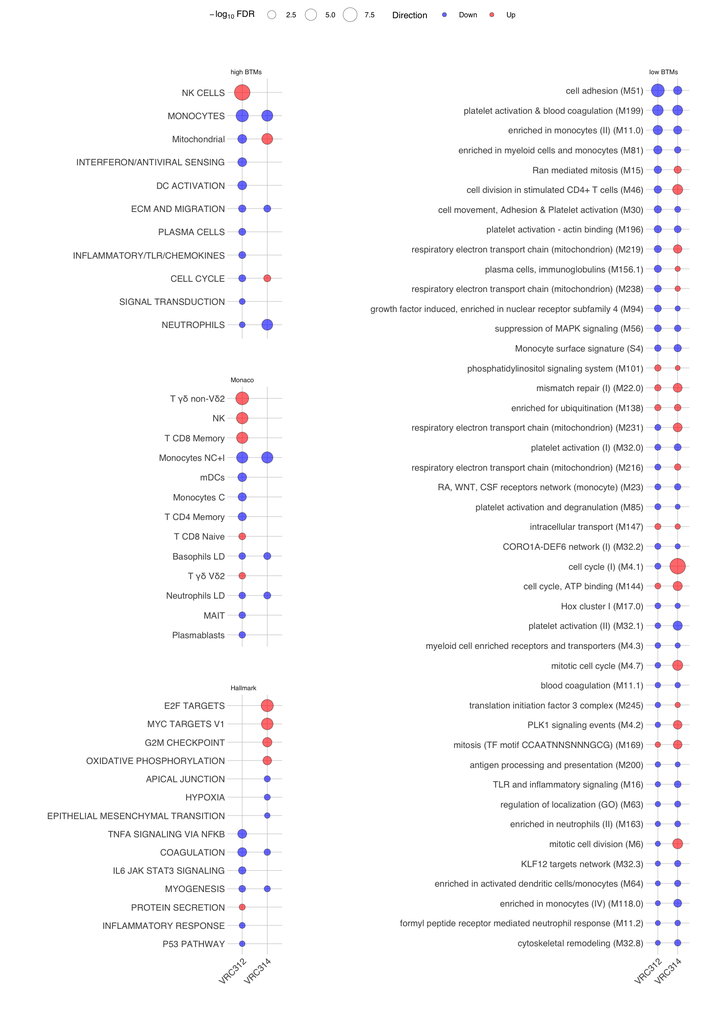

### Visualize GSEA data as bubble plot

Filter based on padj < 0.05.

```r
plotDat <- GSEA_VRC312_VRC314 %>%
  filter(padj < 0.05) %>%
  filter(module_type %in% c("highBTMs", "lowBTMs", "MonacoModules", "BloodGen3Module", "MSigDB_Hallmark_v7.4"))  %>%
  filter(!grepl("TBA", pathway)) %>%
  dplyr::select(study, module_type, pathway, leadingEdge, size, NES, padj) %>%
  mutate(neglogpadj = -log10(padj)) %>%
  dplyr::rename("BH-adj p value (FDR)" = "padj") %>%
  mutate(pathway = gsub("gd", "γδ", pathway)) %>%
  mutate(pathway = gsub("Vd2", "Vδ2", pathway)) %>%
  mutate(pathway = gsub("Vg", "Vγ", pathway)) %>%
  mutate(pathway = gsub("HALLMARK_", "", pathway)) %>%
  mutate(pathway = gsub("_", " ", pathway)) %>%
  mutate(pathway = sub(".*?\\_", "", pathway)) %>%
  group_by(module_type) %>%
  mutate(pathway = fct_reorder(pathway, NES, .desc = TRUE)) %>%
  ungroup() %>%
  filter(!grepl("TBD", pathway)) %>%
  mutate(module_type = factor(module_type, levels = c("highBTMs", "MonacoModules", "lowBTMs", "MSigDB_Hallmark_v7.4", "BloodGen3Module"))) %>%
  arrange(desc(neglogpadj)) %>%
  droplevels()

#plotting options
basetextsize <- 7.5
myfont <- "Helvetica"
bubble_max_size <- 6

TopPlot <- plotDat %>%
  filter(module_type %in% c("highBTMs", "MonacoModules"))  %>%
  ggplot(., aes(x = study, y = pathway)) +
  geom_point(aes(size=neglogpadj, fill = NES), alpha = 0.65, shape=21, stroke = 0.25) +
  scale_size_area(name = expression(-log[10]~adjp), max_size = bubble_max_size) +
      scale_fill_gradient2(low = "blue",
                           mid = "white",
                           high = "red") +
  hrbrthemes::theme_ipsum_es(base_family = myfont, base_size = basetextsize) +
  theme(axis.title.x = element_blank(),
        axis.title.y = element_blank(),
        strip.background = element_blank(),
        strip.text = element_text(size=5.5),
        legend.position = "right",
        axis.text.x = element_text(angle = 45, vjust = 1, hjust=1)) +
facet_wrap(~module_type, scales = "free_y", ncol =2)

MidPlot <- plotDat %>%
  filter(module_type %in% c("lowBTMs", "MSigDB_Hallmark_v7.4"))  %>%
  ggplot(., aes(x = study, y = pathway)) +
  geom_point(aes(size=neglogpadj, fill = NES), alpha = 0.65, shape=21, stroke = 0.25) +
  scale_size_area(name = expression(-log[10]~adjp), max_size = bubble_max_size) +
      scale_fill_gradient2(low = "blue",
                           mid = "white",
                           high = "red") +
  hrbrthemes::theme_ipsum_es(base_family = myfont, base_size = basetextsize) +
  theme(axis.title.x = element_blank(),
        axis.title.y = element_blank(),
        strip.text = element_text(size=5.5),
        strip.background = element_blank(),
        legend.position = "right",
        axis.text.x = element_text(angle = 45, vjust = 1, hjust=1)) +
facet_wrap(~module_type, scales = "free_y", nrow =2)

BottomPlot <- plotDat %>%
  filter(module_type %in% c("BloodGen3Module"))  %>%
  ggplot(., aes(x = study, y = pathway)) +
  geom_point(aes(size=neglogpadj, fill = NES), alpha = 0.65, shape=21, stroke = 0.25) +
  scale_size_area(name = expression(-log[10]~adjp), max_size = bubble_max_size) +
      scale_fill_gradient2(low = "blue",
                           mid = "white",
                           high = "red") +
  hrbrthemes::theme_ipsum_es(base_family = myfont, base_size = basetextsize) +
  theme(axis.title.x = element_blank(),
        axis.title.y = element_blank(),
        strip.text = element_text(size=5.5),
        strip.background = element_blank(),
        legend.position = "right",
        axis.text.x = element_text(angle = 45, vjust = 1, hjust=1)) +
facet_wrap(~module_type, scales = "free_y", ncol =2)
```

### Plot GSEA bubbleplots (Figures S4B of revised manuscript)

Red: enriched in protected/uninfected through 3 months post-vax surveillance Blue: enriched in not protected/infected through 3 months post-vax surveillance

Only modules with BH-adjusted p value (FDR) < 0.05 are shown.

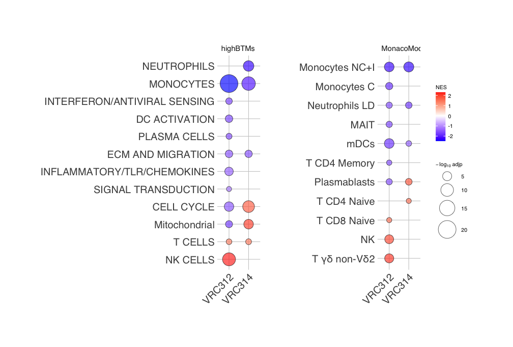

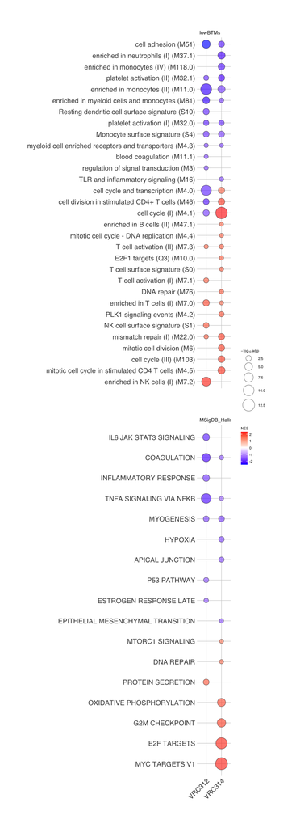

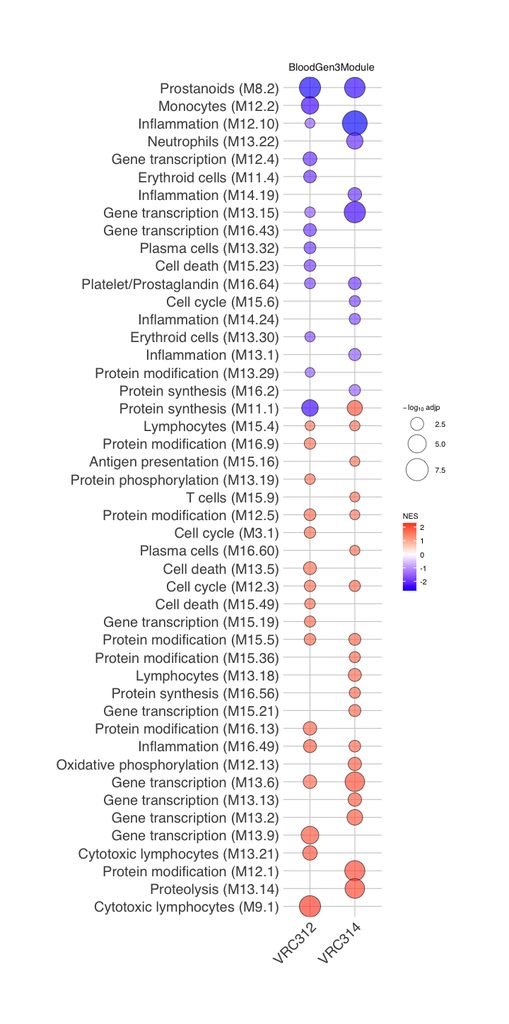

## Ingenuity Pathways analysis

Differential gene expression results (gene symbols), LFCs, p values, and FDRs) for both VRC 312 and VRC 314 were uploaded to IPA, [version June 2023](https://qiagen.my.salesforce.com/sfc/p/#D0000000rgRO/a/6N0000011GyP/jtsB8kUOfFIGWdEtHSS1mcfhQJv3IKapaOKaE0rTzz4). Core analysis was run on genes with unadjusted p<0.2.

```r
#local paths
# IPA_VRC312 <- readxl::read_xls("/Users/tuantran/Library/CloudStorage/GoogleDrive-tuantran@iu.edu/Shared drives/[Sec] IN-MED-INF-TRANLAB/Tran Lab Shared/Projects/Doris Duke PfSPZ Kenya/Tuan PfSPZ/VRC 312 314 Analysis/PfSPZ_PvS_VRC312_IPA_Revised_07162023.xls", skip = 1) %>%
#   mutate(study = "VRC 312")
#
# IPA_VRC314 <- readxl::read_xls("/Users/tuantran/Library/CloudStorage/GoogleDrive-tuantran@iu.edu/Shared drives/[Sec] IN-MED-INF-TRANLAB/Tran Lab Shared/Projects/Doris Duke PfSPZ Kenya/Tuan PfSPZ/VRC 312 314 Analysis/PfSPZ_PvS_VRC314_IPA_Revised_07162023.xls", skip = 1) %>%
#   mutate(study = "VRC 314")

temp <- tempfile(fileext = ".xls")
dl <- drive_download(
  as_id("1N94q0Cur7qkt0PZMtX6EcDVOmMt5j-Lq"), path = temp, overwrite = TRUE)
IPA_VRC312 <- readxl::read_xls(path = dl$local_path, skip = 1) %>%
  mutate(study = "VRC 312")

temp <- tempfile(fileext = ".xls")
dl <- drive_download(
  as_id("1NAgjSINLHusxmrG8Q5MjbU-sV5AF8qMN"), path = temp, overwrite = TRUE)
IPA_VRC314 <- readxl::read_xls(path = dl$local_path, skip = 1) %>%
  mutate(study = "VRC 314")

UpRegPvS <- bind_rows(IPA_VRC312, IPA_VRC314) %>%
  dplyr::select(study, everything())
```

### Filter, clean, prepare data, and plot

Baseline Upstream Regulator Volcano Plot Fig 2E Revised

```r
significance.cutoff <- 0.10
zscore.cutoff <- 2
MoleculeTypes <- c("cytokine", "transcription regulator", "G-protein coupled receptor", "chemical - endogenous non-mammalian", "chemical - endogenous mammalian",
                  "group", "chemical toxicant", "microRNA", "enzyme", "translation regulator")
# MoleculeTypes <- c("cytokine", "transcription regulator", "G-protein coupled receptor", "chemical - endogenous non-mammalian", "chemical drug", "chemical - endogenous mammalian",
#                   "complex", "group", "chemical toxicant", "microRNA", "enzyme", "translation regulator")
# UpRegPvS_foo <- UpRegPvS %>%
#   filter(`p-value of overlap`<0.05) %>%
#   filter(Comparison == "Baseline Placebo")
UpRegPvS_foo <- UpRegPvS %>%
  mutate(study = factor(study, levels = c("VRC 312", "VRC 314"))) %>%
  dplyr::select(study, "Upstream Regulator", "Molecule Type", "Activation z-score", "p-value of overlap", "B-H corrected p-value") %>%
  dplyr::rename(MoleculeType = "Molecule Type") %>%
  mutate(`-log10(p-value of overlap)` = -log10(`p-value of overlap`)) %>%
  mutate(`-log10(B-H adj. p value)` = -log10(`B-H corrected p-value`)) %>%
  mutate(`Upstream Regulator` = gsub("\\(and other miRNAs.*", "", `Upstream Regulator`)) %>%
  mutate(significant = ifelse(`B-H corrected p-value` < significance.cutoff & `Activation z-score` >= 2 |
                                `B-H corrected p-value`< significance.cutoff & `Activation z-score` <= -2, TRUE, FALSE)) %>%
  mutate(color = ifelse(significant == TRUE & `Activation z-score`>0, "red", "grey50")) %>%
  mutate(color = ifelse(significant == TRUE & `Activation z-score` < 0, "blue", color)) %>%
  mutate(label = ifelse(significant == TRUE, `Upstream Regulator`, ""))  %>%
  filter(MoleculeType %in% MoleculeTypes) %>%
  mutate(label = gsub("Salmonella enterica serotype abortus equi lipopolysaccharide", "Salmonella enterica LPS", label)) %>%
  mutate(label = gsub("salmonella minnesota R595 lipopolysaccharides", "Salmonella R595 LPS", label)) %>% #replacing long names with shorter names/synonyms
  mutate(label = gsub("tetradecanoylphorbol acetate", "PMA", label)) %>% #replacing long names with shorter names/synonyms
  mutate(label = gsub("sphingosine-1-phosphate", "S1P", label)) %>% #replacing long names with shorter names/synonyms
  mutate(label = gsub("beta-estradiol", "β-estradiol", label)) %>% #replacing long names with shorter names/synonyms
  mutate(label = gsub("Interferon alpha", "IFNα", label)) %>% #replacing long names with shorter names/synonyms
  mutate(label = gsub("IL1B", "IL1", label)) %>% #replacing long names with shorter names/synonyms
  mutate(label = gsub("IL1", "IL1β", label)) %>% #replacing long names with shorter names/synonyms
  mutate(label = gsub("IFN Beta", "IFNβ", label)) %>% #replacing long names with shorter names/synonyms
  mutate(label = gsub("Ifnar", "IFNAR", label)) %>% #replacing long names with shorter names/synonyms
  mutate(label = gsub("Tgf beta", "TGFβ", label)) %>% #replacing long names with shorter names/synonyms
  mutate(label = gsub("G protein alphai", "Giα protein", label)) %>% #replacing long names with shorter names/synonyms
  mutate(label = gsub("Nfat \\(family\\)", "NFAT", label)) %>% #replacing long names with shorter names/synonyms
  mutate(label = gsub("Alpha ", "α-", label)) %>% #replacing long names with shorter names/synonyms
 # mutate(label = gsub("LPSs", "LPS", label)) %>% #replacing long names with shorter names/synonyms
  mutate(label = gsub("lipopolysaccharide", "LPS", label)) %>% #replacing long names with shorter names/synonyms
  mutate(label = gsub("medroxyprogesterone acetate", "MPA", label))

#identify upstream regulators that appear as significant in more than one comparison
foo <- UpRegPvS_foo %>%
  dplyr::filter(significant == TRUE) %>%
  group_by(label) %>%
  summarize(n = n()) %>%
  dplyr::filter(n > 1)


#https://datavizpyr.com/how-to-add-labels-to-select-points-with-ggrepel/
UpRegPvS_label_df <-  UpRegPvS_foo %>%
  dplyr::filter(label %in% foo$label | #limit labels due to space limitations
                  (`Activation z-score` < -2 & `B-H corrected p-value` < 0.00001 & study == "VRC 312")|
                  (`Activation z-score` > 2 & `B-H corrected p-value` < 0.00001 & study == "VRC 312")|
                  (`Activation z-score` < -2 & `B-H corrected p-value` < significance.cutoff & study == "VRC 314")|
                  (`Activation z-score` > 2 & `B-H corrected p-value` < significance.cutoff & study == "VRC 314")) #limit label to upstream regulators that appear as significant in more than one comparison

myUpRegPlot <- UpRegPvS_foo %>%
  ggplot(., aes(x = `Activation z-score`, y = `-log10(B-H adj. p value)`, label = label)) +
  geom_point(color = as.character(UpRegPvS_foo$color), alpha = 0.6) +
  geom_hline(yintercept = -log10(significance.cutoff), color = "blue", linetype = "dotted") +
  geom_vline(xintercept = c((-1*zscore.cutoff), zscore.cutoff), color = "red", linetype = "dotted") +
  ggrepel::geom_label_repel(data = UpRegPvS_label_df, force = 15, force_pull = 2, size = 3.6, max.overlaps = 20,
                            label.size = NA,
                            label.padding = 0.02,
                            box.padding = 0.02,
                            fill = alpha(c("white"),0.8)) +
  theme_bw() +
  xlab("activation z-score at pre-immunization baseline") +
  xlim(-6,6)+
  facet_wrap(~study, nrow = 2, ncol = 2) +
  theme(axis.text=element_text(size=16),
        axis.title=element_text(size=16),
        strip.text = element_text(size=16),
        strip.background = element_blank())
```

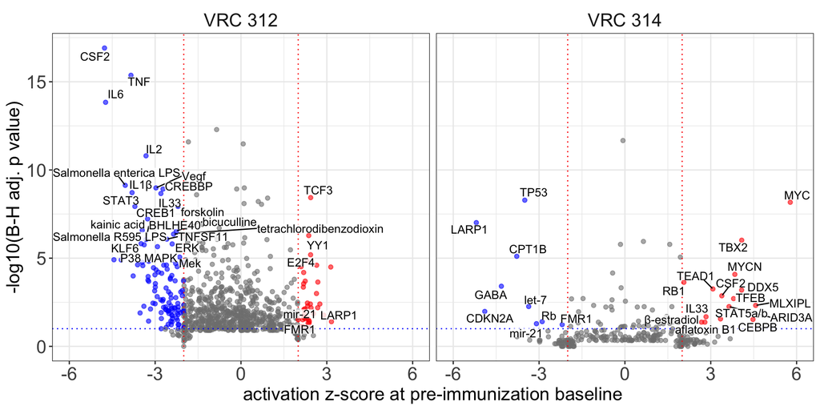

```r
myUpRegPlot
```